# Sapling_old_new_separate

Ryan Fass

2023-01-18

Saplings Old and New Separate means: same as tree data, where I separated the old and new experiments into two different csv’s so that processing is a little more streamline. I separated the SaplingsMeta_data in Excel. For Old Experiment: I deleted all of the New Experiment plots and the two extra controls (190 & 191), using Sort in excel. For New Experiment: I only added Old Experiment Control plots (PostBurnYear1 and changed to PreBurn) and (PostBurnYear2 and changed to PostBurnYear1) **This change in monitoring_status was to mimic the year of survey for the New Experiment.**

```r
library(tidyverse)
```

```r
library(ggplot2)
library(here)
library(janitor)
library(knitr)
library(dplyr)
library(patchwork)
```

Reading in the two sapling csv’s (old and new)

```r
saplings_all_old_data <- read_csv(here('saplings_all_old_data.csv'))
```

```
## ──────────────────────────────────────────────────────── Delimiter: "," chr
## (17): macro_plot_name, monitoring_status, date, status, comment, top_kil... dbl
## (8): ...1, size_cl_dia, avg_ht, tag_no, basal_resprout_height_cm, basal...
```

```r
saplings_all_new_data <- read_csv(here('saplings_all_new_data.csv'))
```

```
## ──────────────────────────────────────────────────────── Delimiter: "," chr
## (16): macro_plot_name, monitoring_status, date, status, comment, top_kil... dbl
## (9): ...1, size_cl_dia, avg_ht, tag_no, basal_resprout_height_cm, basal...
```

Take both the trees old experiment data and the tree new experiment data and select just the QUKE species.Then change the status_x values (L = live and D = dead). Create a new column call final_status that has values = alive, dead, topkill.

```r
saplings_tk_status_old <- saplings_all_old_data %>%
  select(macro_plot_name, monitoring_status, status, species_symbol,  treatment_burn,  experiment, top_kill_y_n) %>%
  filter(species_symbol %in% c("QUKE")) %>%
  mutate(live = status == "L") %>%
  mutate(dead = status == "D",
         final_status = case_when(live == TRUE ~ "alive",
                                  dead == TRUE & top_kill_y_n == "N" ~ "dead",
                                  dead == TRUE & top_kill_y_n == "Y" ~ "topkill",
                                  dead == TRUE & is.na(top_kill_y_n) == TRUE ~ "dead"))

saplings_tk_status_new <- saplings_all_new_data %>%
  select(macro_plot_name, monitoring_status, status, species_symbol,  treatment_burn,  experiment, top_kill_y_n) %>%
  filter(species_symbol %in% c("QUKE")) %>%
  mutate(live = status == "L") %>%
  mutate(dead = status == "D",
         final_status = case_when(live == TRUE ~ "alive",
                                  dead == TRUE & top_kill_y_n == "N" ~ "dead",
                                  dead == TRUE & top_kill_y_n == "Y" ~ "topkill",
                                  dead == TRUE & is.na(top_kill_y_n) == TRUE ~ "dead"))
```

For the Old and New experiments, I created a data frame that has the columns that I want to show in the table (using group_by) and then used the summarise fuction to count the Alive, Dead and Topkill in the final status.

```r
group_sap_tk_old = saplings_tk_status_old %>%
  group_by(monitoring_status, treatment_burn, experiment) %>%
  summarise(live = sum(final_status== "alive"),
            dead = sum(final_status== "dead"),
            topkill = sum(final_status== "topkill")) %>%
  mutate(monitoring_status = as.factor(monitoring_status))
```

```
## can override using the `.groups` argument.
```

```r
group_sap_tk_new = saplings_tk_status_new %>%
  group_by(monitoring_status, treatment_burn, experiment) %>%
  summarise(live = sum(final_status== "alive"),
            dead = sum(final_status== "dead"),
            topkill = sum(final_status== "topkill")) %>%
 mutate(monitoring_status = as.factor(monitoring_status))
```

```
## can override using the `.groups` argument.
```

Reordering the data frame so that the monitoring_status reads logically. Then using ‘kable’ to create the tables.

```r
group_sap_tk_old_reorder <- group_sap_tk_old %>%
  mutate(monitoring_status=fct_relevel(monitoring_status, "PreBurn", "PostBurnYear1", "PostBurnYear2")) %>%
  arrange(monitoring_status)# Arranges the data frame by this variable

kable(group_sap_tk_old_reorder, format = "markdown", col.names = c("Monitoring Status", "Treatment", "Experiment", "Alive", "Dead", "Topkill"), align = "llcc", digits = 3,caption = "Number of Alive, Dead and Topkill QUKE Saplings by burn treatment")
```

Number of Alive, Dead and Topkill QUKE Saplings by burn treatment

| Monitoring Status | Treatment | Experiment | Alive | Dead | Topkill |
| --- | --- | --- | --- | --- | --- |
| PreBurn | control | old | 34 | 0 | 0 |
| PreBurn | post_budbreak | old | 42 | 0 | 0 |
| PreBurn | pre_budbreak | old | 58 | 0 | 0 |
| PostBurnYear1 | control | old | 34 | 0 | 0 |
| PostBurnYear1 | post_budbreak | old | 9 | 1 | 32 |
| PostBurnYear1 | pre_budbreak | old | 27 | 3 | 28 |
| PostBurnYear2 | control | old | 36 | 0 | 0 |
| PostBurnYear2 | post_budbreak | old | 15 | 1 | 31 |
| PostBurnYear2 | pre_budbreak | old | 33 | 4 | 20 |

```r
group_sap_tk_new_reorder <- group_sap_tk_new %>%
  mutate(monitoring_status=fct_relevel(monitoring_status, "PreBurn", "PostBurnYear1", "PostBurnYear2")) %>%
  arrange(monitoring_status)# Arranges the data frame by this variable

kable(group_sap_tk_new_reorder, format = "markdown", col.names = c("Monitoring Status", "Treatment", "Experiment", "Alive", "Dead", "Topkill"), align = "llcc", digits = 3,caption = "Number of Alive, Dead and Topkill QUKE Saplings by burn treatment")
```

Number of Alive, Dead and Topkill QUKE Saplings by burn treatment

| Monitoring Status | Treatment | Experiment | Alive | Dead | Topkill |
| --- | --- | --- | --- | --- | --- |
| PreBurn | control | new | 42 | 0 | 0 |
| PreBurn | post_budbreak | new | 16 | 1 | 0 |
| PreBurn | pre_budbreak | new | 37 | 0 | 0 |
| PostBurnYear1 | control | new | 44 | 0 | 0 |
| PostBurnYear1 | post_budbreak | new | 8 | 2 | 8 |
| PostBurnYear1 | pre_budbreak | new | 19 | 4 | 14 |

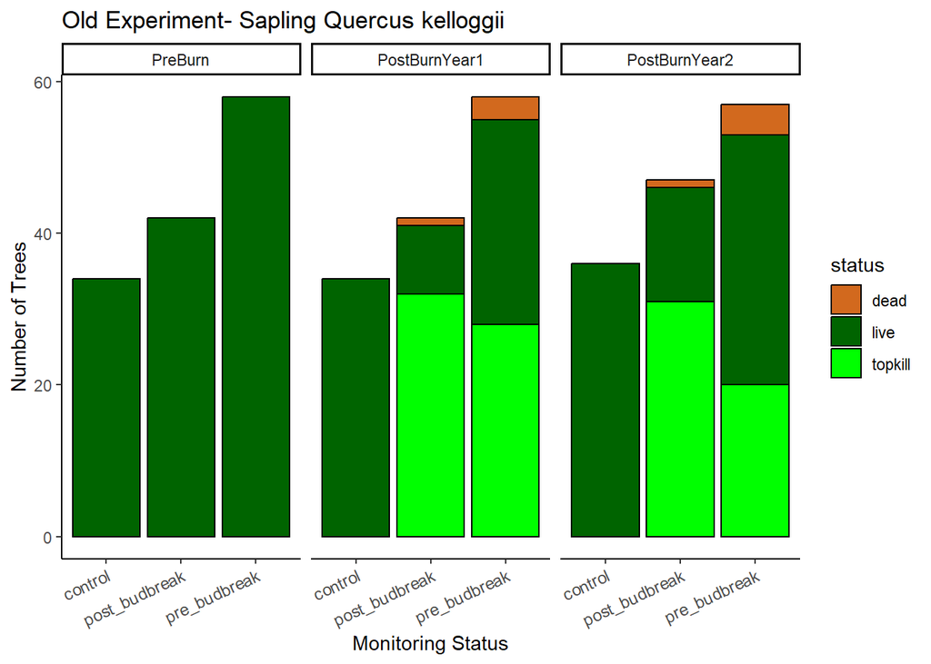

```r
plot_sap_tk_status_old <- group_sap_tk_old_reorder %>%
  pivot_longer(cols = c('live', 'dead', 'topkill'),
               names_to = 'status',
               values_to = 'count')


ggplot(data = plot_sap_tk_status_old, aes(fill = status, x = treatment_burn, y = count))+
  geom_bar(stat= "identity",
           position= "stack",
           color="black")+
   scale_fill_manual(values = c('chocolate', 'darkgreen', 'green'))+
  #geom_text(aes(y = 30,label= treatment_burn),
  #          position = position_dodge(width = .9),
   #         angle = 90,
    #        fontface= "bold")+
  facet_wrap(~monitoring_status)+
  ylab('Number of Trees') +
  ggtitle("Old Experiment- Sapling Quercus kelloggii")+
  xlab('Monitoring Status')+
  theme_classic()+
  theme(axis.text.x = element_text(size =9, angle = 25, hjust =1)) #puts a tilt on the x-axis labels
```

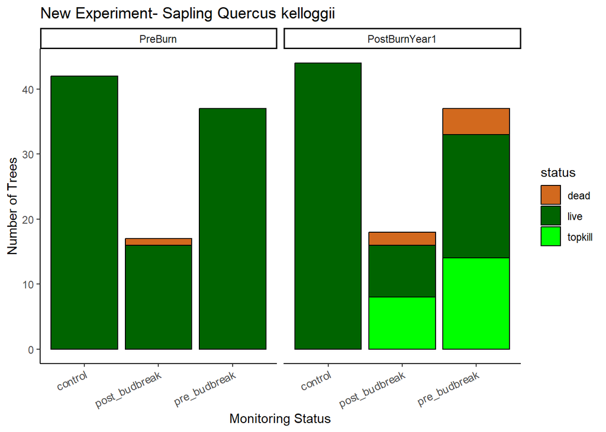

```r
plot_sap_tk_status_new <- group_sap_tk_new_reorder %>%
  pivot_longer(cols = c('live', 'dead', 'topkill'),
               names_to = 'status',
               values_to = 'count')


ggplot(data = plot_sap_tk_status_new, aes(fill = status, x = treatment_burn, y = count))+
  geom_bar(stat= "identity",
           position= "stack",
           color="black")+
   scale_fill_manual(values = c('chocolate', 'darkgreen', 'green'))+
 # geom_text(aes(y = 30,label= treatment_burn),
 #           position = position_dodge(width = .9),
 #           angle = 90,
 #           fontface= "bold")+
  facet_wrap(~monitoring_status)+
  ylab('Number of Trees') +
  ggtitle("New Experiment- Sapling Quercus kelloggii")+
  xlab('Monitoring Status')+
  theme_classic()+
   theme(axis.text.x = element_text(size =9, angle = 25, hjust =1))
```